# Specific Stage Analysis

# Specific Stage Analysis

## Run the Analysis

```r
#Run Specific Stage Analysis ----
SS_results <- SS(Site, Quantiles)
```

## Cleanup

Now we check results for stage and discharge to make sure there are no outliers. In the figure below, we can see some scatter around our target discharge quantiles.

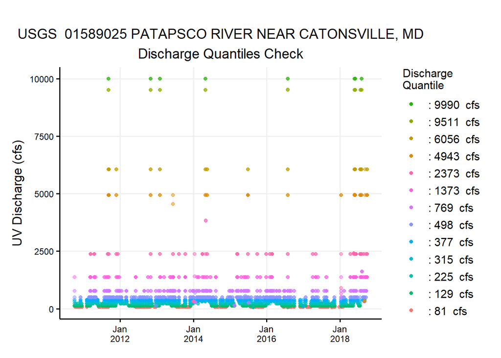

A simple dplyr pipe uses mutate to calculate the percent difference between the calculated discharge and the discharge of interest. Results are then filtered to select only those values less than the percent difference specified by Sensitivity.

```r
SS_results_clean <- SS_results %>%
                    mutate(pc_diff = (Flow_Inst-Quantflow)/Quantflow) %>%
                    filter(pc_diff > -Sensitivity & pc_diff < Sensitivity)
```

## Post-outlier Check

Now we check results again to make sure all outliers have been removed.

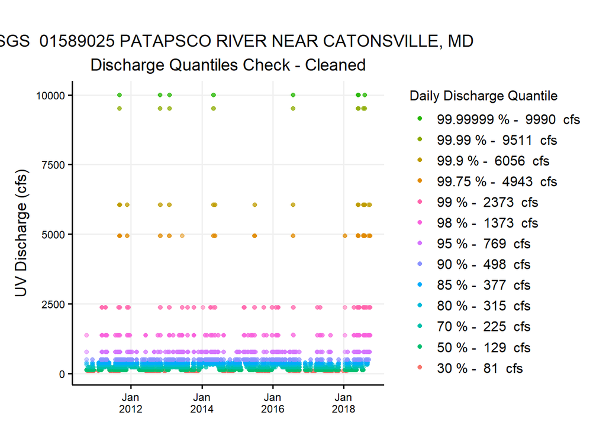

# Specific Stage Result Plots

Now that outliers have been removed, we can print all our results. First in one plot for all quantiles. Next are individual plots for all target quantiles

## All Quantiles Plot

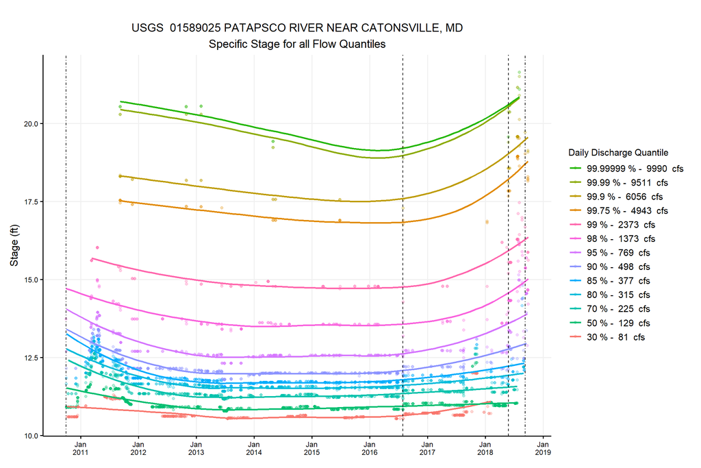

## Target Quantile Plots

[figure not shown]

[figure not shown]

[figure not shown]

[figure not shown]

[figure not shown]

[figure not shown]

[figure not shown]

[figure not shown]

[figure not shown]

[figure not shown]

[figure not shown]

[figure not shown]

[1 more figures not shown]

# Let’s explore site measurements (This is for all sites, not specific to the above analysis)

## Download site measurement data and derive secondary stats

```r
Site <- Site
Sites <- c("01589000","01589025","01589035")

meas <- readNWISmeas(Sites,
                     startDate = startDate,
                     endDate = "",
                     tz = "America/New_York",
                     expanded = TRUE,
                     convertType = TRUE)

#meas
#area*velocity = discharge
#area/width = height
#Fr = Velocity/sqrt(32.2*depth) <-- check that this is correct

meas <- meas %>%
  mutate(chan_depth = chan_area/chan_width) %>%
  mutate(Froude = chan_velocity/(sqrt(32.2*chan_depth)))
# Fr <1 - subcritical flow
# Fr >1 - supercritical flow
# Fr = critical flow
```

## Plot Estimated Froude number in time

[figure not shown]

##Plot estimated channel depth

[figure not shown]

##Plot measured channel area

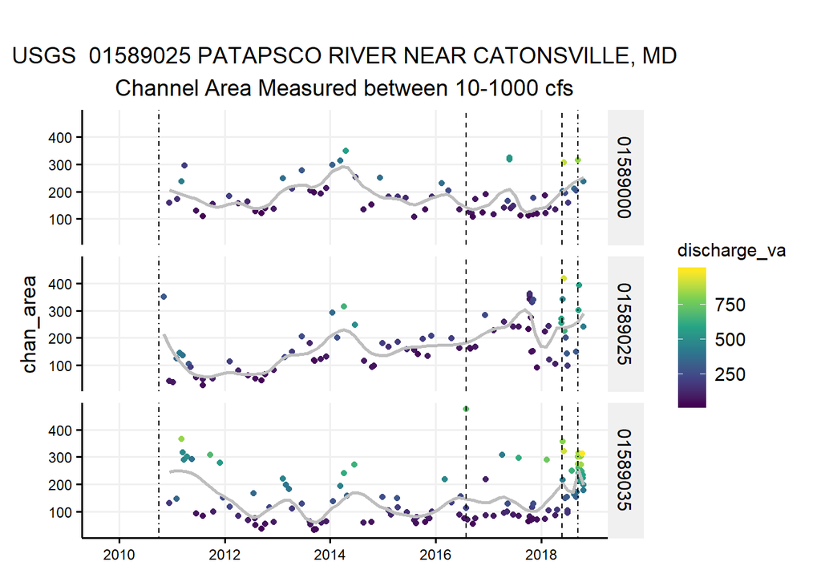

##Plot measured channel velocity

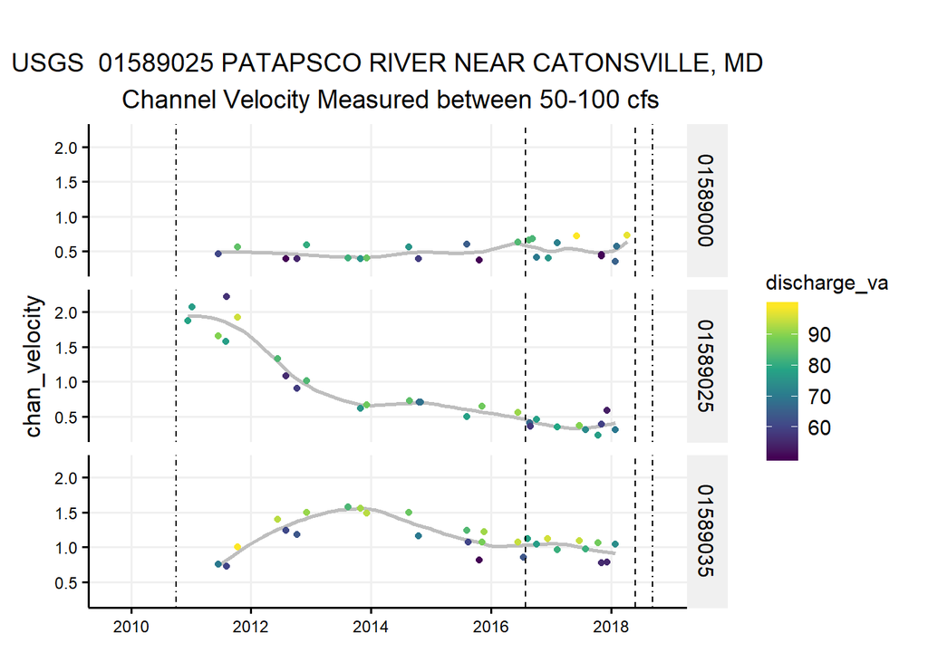

##Plot measured channel velocity~discharge

[figure not shown]

###Yearly Animation

[output not shown]

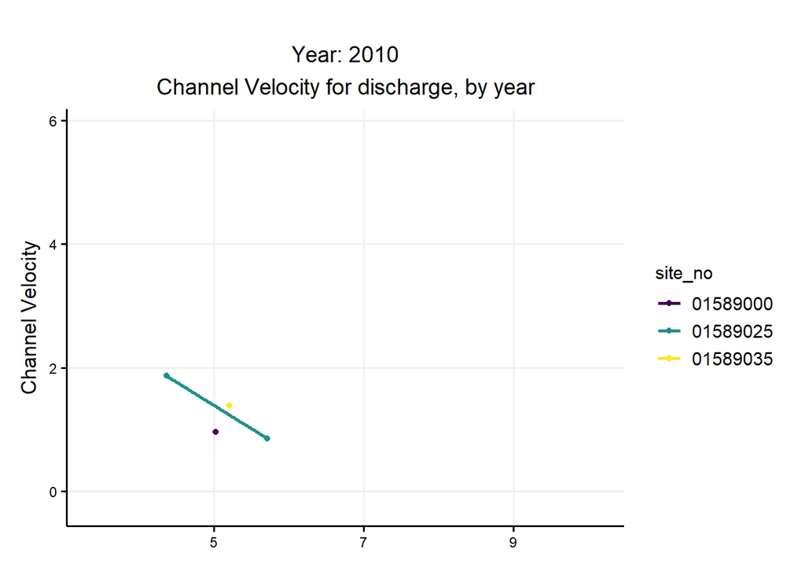

## Plot froude~discharge+Year

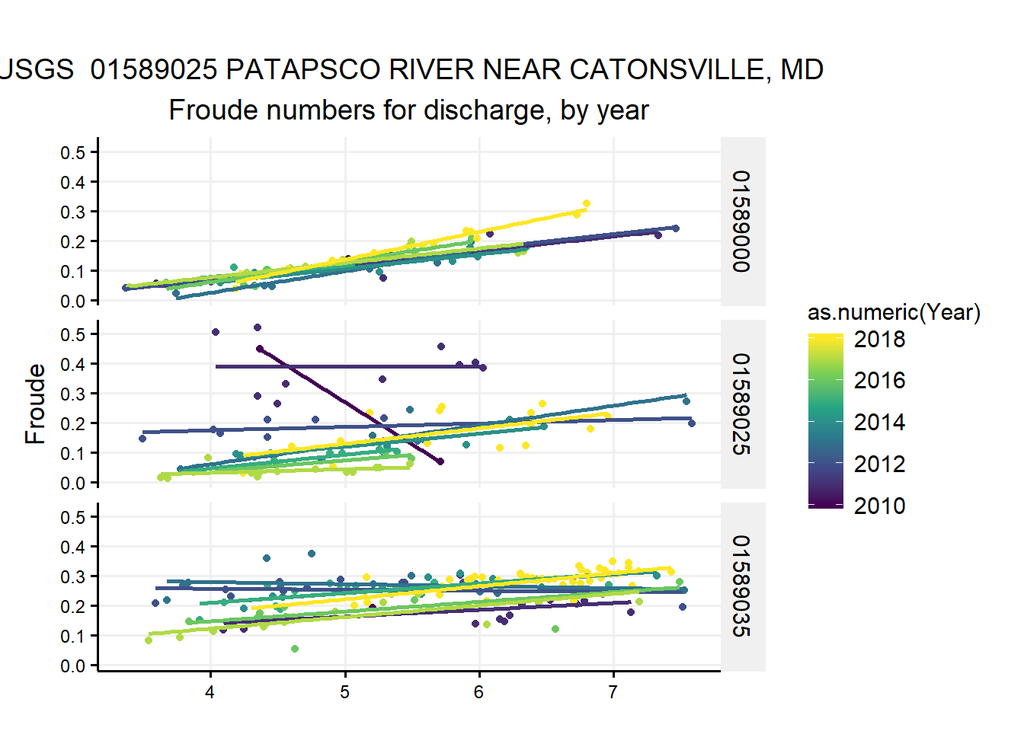

###Yearly Animation

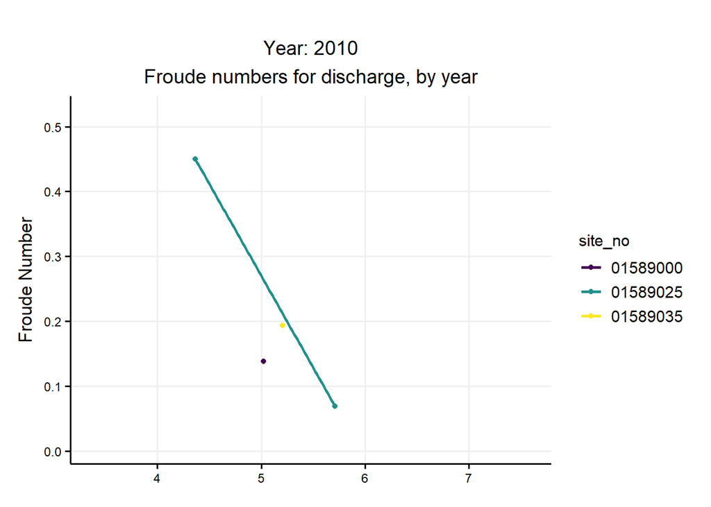